# Mobike Data Exploration

## Preliminary Wrangling

> Mobike单车数据，包括 orderid, bikeid, userid, start_time, start_location_x, start_location_y, end_time, end_location_x, end_location_y, track

#### 导入包

```python
# import all packages and set plots to be embedded inline
import numpy as np
import pandas as pd
import matplotlib.pyplot as plt
import seaborn as sb

%matplotlib inline
```

#### 导入数据

```python
mobike = pd.read_csv('mobike_shanghai_sample_updated.csv')
```

```python
mobike.head()
```

|  | orderid | bikeid | userid | start_time | start_location_x | start_location_y | end_time | end_location_x | end_location_y | track |
| --- | --- | --- | --- | --- | --- | --- | --- | --- | --- | --- |
| 0 | 78387 | 158357 | 10080 | 2016-08-20 06:57 | 121.348 | 31.389 | 2016-08-20 07:04 | 121.357 | 31.388 | 121.347,31.392#121.348,31.389#121.349,31.390#1... |
| 1 | 891333 | 92776 | 6605 | 2016-08-29 19:09 | 121.508 | 31.279 | 2016-08-29 19:31 | 121.489 | 31.271 | 121.489,31.270#121.489,31.271#121.490,31.270#1... |
| 2 | 1106623 | 152045 | 8876 | 2016-08-13 16:17 | 121.383 | 31.254 | 2016-08-13 16:36 | 121.405 | 31.248 | 121.381,31.251#121.382,31.251#121.382,31.252#1... |
| 3 | 1389484 | 196259 | 10648 | 2016-08-23 21:34 | 121.484 | 31.320 | 2016-08-23 21:43 | 121.471 | 31.325 | 121.471,31.325#121.472,31.325#121.473,31.324#1... |
| 4 | 188537 | 78208 | 11735 | 2016-08-16 07:32 | 121.407 | 31.292 | 2016-08-16 07:41 | 121.418 | 31.288 | 121.407,31.291#121.407,31.292#121.408,31.291#1... |

#### 查看数据.info()信息

```python
mobike.info()
```

```
<class 'pandas.core.frame.DataFrame'>
RangeIndex: 102361 entries, 0 to 102360
Data columns (total 10 columns):
orderid             102361 non-null int64
bikeid              102361 non-null int64
userid              102361 non-null int64
start_time          102361 non-null object
start_location_x    102361 non-null float64
start_location_y    102361 non-null float64
end_time            102361 non-null object
end_location_x      102361 non-null float64
end_location_y      102361 non-null float64
track               102361 non-null object
dtypes: float64(4), int64(3), object(3)
memory usage: 7.8+ MB
```

```python
mobike['userid'] = mobike['userid'].astype('category')
mobike['bikeid'] = mobike['bikeid'].astype('category')
```

```python
sum(mobike.bikeid.duplicated())
```

```
23299
```

```python
sum(mobike.orderid.duplicated())
```

```
0
```

```python
sum(mobike.userid.duplicated())
```

```
85474
```

### start_time和end_time转为时间类型

```python
# start_time和end_time转为时间类型
mobike.start_time = pd.to_datetime(mobike.start_time)
mobike.end_time = pd.to_datetime(mobike.end_time)
```

### What is the structure of your dataset?

> 102361条摩拜单车订单数据信息：包括订单编号orderid, 车辆编号bikeid, 用户编号userid, 订单开始时间start_time, start_location_x,start_location_y,end_time, end_location_x,end_location_y,track

### What is/are the main feature(s) of interest in your dataset?

> 什么时间什么位置的订单最多？

### What features in the dataset do you think will help support your investigation into your feature(s) of interest?

- 利用start_time, end_time得到订单最多的时间段，
- start_location_x, start_location_y,得到订单最多的地段，
- 通过track骑行路线进行辅助。

## Univariate Exploration

### 提取start_time的 星期几（1-7）；月份（1-12）；时间Hour（0-23）

```python
# 提取start_time的 星期几（1-7）；月份（1-12）；时间Hour（0-23）
weekdays = []
months = []
hours = []
days = []
end_hours = []
for i in range(len(mobike)):
    months.append(mobike.start_time[i].month)
    weekdays.append(mobike.start_time[i].isoweekday())
    hours.append(mobike.start_time[i].hour)
    end_hours.append(mobike.end_time[i].hour)
    days.append(mobike.start_time[i].day)
```

```python
mobike['weekdays'] = weekdays
mobike['months'] = months
mobike['hours'] = hours
mobike['end_hours'] = end_hours
mobike['days'] = days
```

```python
mobike.info()
```

```
<class 'pandas.core.frame.DataFrame'>
RangeIndex: 102361 entries, 0 to 102360
Data columns (total 15 columns):
orderid             102361 non-null int64
bikeid              102361 non-null category
userid              102361 non-null category
start_time          102361 non-null datetime64[ns]
start_location_x    102361 non-null float64
start_location_y    102361 non-null float64
end_time            102361 non-null datetime64[ns]
end_location_x      102361 non-null float64
end_location_y      102361 non-null float64
track               102361 non-null object
weekdays            102361 non-null int64
months              102361 non-null int64
hours               102361 non-null int64
end_hours           102361 non-null int64
days                102361 non-null int64
dtypes: category(2), datetime64[ns](2), float64(4), int64(6), object(1)
memory usage: 14.6+ MB
```

### Create the plot of weekday- counts

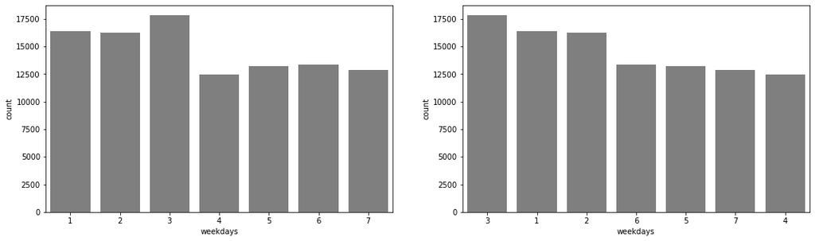

```python
# create the plot of weekday
weekday_order = mobike['weekdays'].value_counts().index
plt.figure(figsize = [18,5])
base_color = sb.color_palette()[7]
plt.subplot(1,2,1)
sb.countplot(data = mobike, x='weekdays', color =base_color)
plt.subplot(1,2,2)
sb.countplot(data = mobike, x='weekdays', color =base_color,order = weekday_order)
```

#### 结论1

> - 周一周二周三相比周四周五周六周日明显有更多订单

### create the plot of hour- counts, using start_time

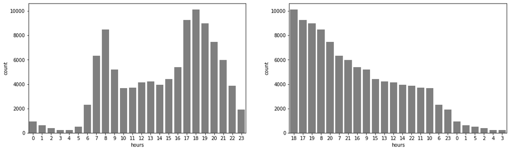

```python
# create the plot of hour
hour_order = mobike['hours'].value_counts().index
plt.figure(figsize = [18,5])
plt.subplot(1,2,1)
sb.countplot(data = mobike, x='hours', color =base_color)
plt.subplot(1,2,2)
sb.countplot(data = mobike, x='hours', color =base_color, order = hour_order)
```

#### 结论2

> - 早上7-9点，晚上17-20点订单最多

### create the plot of hour- counts, using end_time

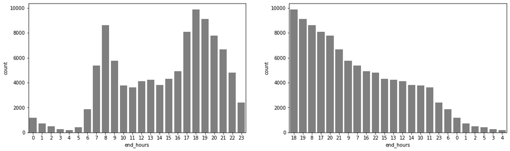

```python
# create the plot of end_hour
hour_order = mobike['end_hours'].value_counts().index
plt.figure(figsize = [18,5])
plt.subplot(1,2,1)
sb.countplot(data = mobike, x='end_hours', color =base_color)
plt.subplot(1,2,2)
sb.countplot(data = mobike, x='end_hours', color =base_color, order = hour_order)
```

> 辅助结论2：
> - 骑行时长大都在1小时内，所以，按照end_time得到的订单数和start_time得到的订单数在同一小时内基本保持一致。

### create the plot of day

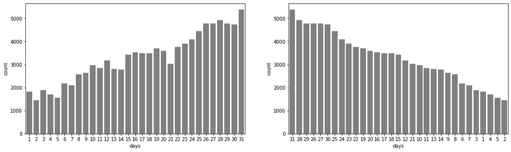

```python
# create the plot of day
day_order = mobike['days'].value_counts().index
plt.figure(figsize = [18,5])
plt.subplot(1,2,1)
sb.countplot(data = mobike, x='days', color =base_color)
plt.subplot(1,2,2)
sb.countplot(data = mobike, x='days', color =base_color, order = day_order)
```

### 骑行订单在8月份从1号-31号 有线性增加的趋势

> - 推测1：在此期间，摩拜单车正在进行推广营销。
> - 推测2：找到了周一到周三的counts多的原因：因为2016年8月29，30，31日正好是周一周二周三。所以，统计时，周一、周二、周三多了。

### 增加变量`骑行时长`到mobike数据

```python
# 增加变量`骑行时长`到mobike数据
mobike['time_length'] = mobike['end_time'] - mobike['start_time']
# 用 apply, lambda, 更改time_length
mobike['time_length'] = mobike['time_length'].apply(lambda x: (x.seconds)/60)
```

```python
mobike['time_length'].describe()
```

```
count    102361.000000
mean         17.026348
std          23.436665
min           1.000000
25%           7.000000
50%          12.000000
75%          20.000000
max        1408.000000
Name: time_length, dtype: float64
```

### time_length.describe() 发现,最大值为 1408 min。考虑到不可能连续骑车1408分，因而认为是异常值。

> - #### 下一步： #### binsize 设置为20 min， 来观察

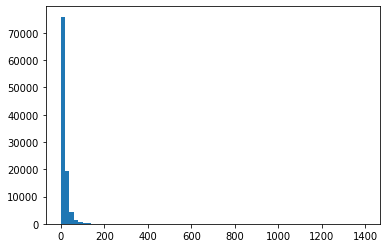

```python
bin_edges = np.arange(0, mobike['time_length'].max()+1, 20)
plt.hist(data = mobike, x = 'time_length', bins = bin_edges)
```

### 上图分布太窄，下一步对该图进行修正

```python
outliers_200min = []
outliers_200min_index = []
for i in range(len(mobike)):
    if mobike['time_length'][i] > 125:
        outliers_200min.append(mobike['time_length'][i])
        outliers_200min_index.append(i)
```

```python
len(outliers_200min)
```

```
396
```

### outliers分析：

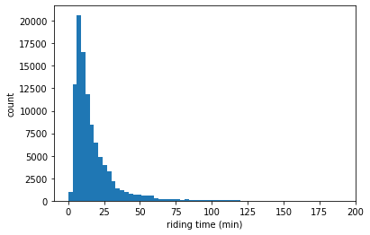

```python
bin_edges = np.arange(0, mobike['time_length'].max()+1, 3)
plt.hist(data = mobike, x = 'time_length', bins = bin_edges)
plt.xlim(-10,200)
plt.ylabel('count')
plt.xlabel('riding time (min)')
```

### 为了更好地观察riting time的数据，下一步对坐标轴进行变换

```python
bins = 10 ** np.arange(-1, 2.7, 0.05)
ticks = [0.1,0.3,1,3,10,30,100,300]
labels = ['{}'.format(v) for v in ticks]
plt.hist(data = mobike, x = 'time_length', bins = bins)
plt.xscale('log')
plt.xticks(ticks,labels)
```

[output not shown]

### 从该分布图中，可以看出骑行时长最多的在 [4,15] min

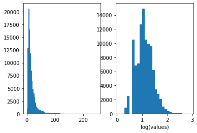

```python
# histogram on left:natural units

plt.subplot(1,2,1)
bin_edges = np.arange(0, mobike['time_length'].max()+1, 4)
bin_edges = np.arange(0,250,3)
plt.hist(data = mobike, x = 'time_length',bins= bin_edges)
# histogram on right: directly log-transform data
plt.subplot(1,2,2)
log_data = np.log10(mobike['time_length'])
log_bin_edges = np.arange(0.1, 3, 0.1)
plt.hist(log_data, bins = log_bin_edges)
plt.xlabel('log(values)')
```

```python
mobike.start_location_x.describe()
```

```
count    102361.000000
mean        121.454144
std           0.060862
min         121.173000
25%         121.415000
50%         121.456000
75%         121.497000
max         121.970000
Name: start_location_x, dtype: float64
```

### 下面画直方图查看出发位置的经度、纬度的范围和分布

```
(30.831, 31.487000000000002)
```

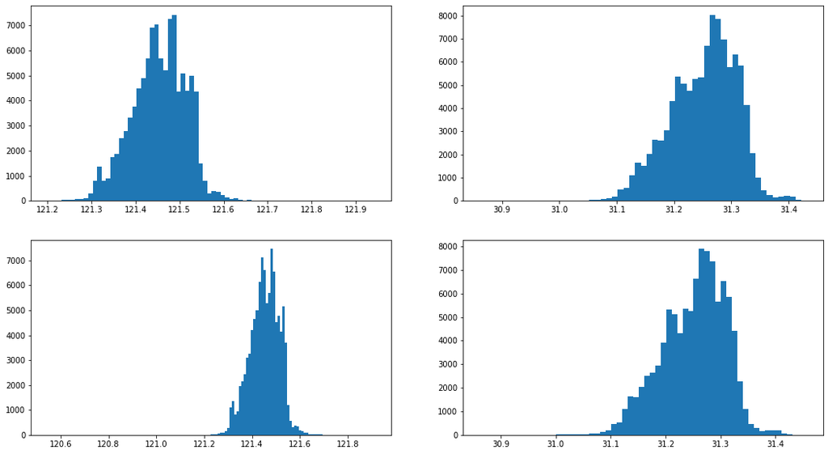

```python
# histogram of start_locationm
plt.figure(figsize = [18,10])
plt.subplot(2,2,1)
temp = 'start_location_x'
bin_edges = np.arange(mobike[temp].min()-0.01, mobike[temp].max()+0.01, 0.01)
plt.hist(data = mobike, x = temp,bins= bin_edges)
plt.xlim(mobike[temp].min()-0.01, mobike[temp].max()+0.01)

plt.subplot(2,2,2)
temp = 'start_location_y'
bin_edges = np.arange(mobike[temp].min()-0.01, mobike[temp].max()+0.01, 0.01)
plt.hist(data = mobike, x = temp,bins= bin_edges)
plt.xlim(mobike[temp].min()-0.01, mobike[temp].max()+0.01)

plt.subplot(2,2,3)
temp = 'end_location_x'
bin_edges = np.arange(mobike[temp].min()-0.01, mobike[temp].max()+0.01, 0.01)
plt.hist(data = mobike, x = temp,bins= bin_edges)
plt.xlim(mobike[temp].min()-0.01, mobike[temp].max()+0.01)

plt.subplot(2,2,4)
temp = 'end_location_y'
bin_edges = np.arange(mobike[temp].min()-0.01, mobike[temp].max()+0.01, 0.01)
plt.hist(data = mobike, x = temp,bins= bin_edges)
plt.xlim(mobike[temp].min()-0.01, mobike[temp].max()+0.01)
```

### 以下代码可以查看userid 和 bikeid的分布，得到大概的 用户使用频率分布 和 bike使用频率分布。但由于运行时间过长，且后续未进一步分析，这里注释掉了。

```python
# create the plot of userid
#plt.figure(figsize = [18,5])
#temp = 'userid'
#plt.subplot(1,2,1)
#sb.countplot(data = mobike, x=temp, color =base_color)
#temp = 'bikeid'
#plt.subplot(1,2,2)
#sb.countplot(data = mobike, x=temp, color =base_color)
```

### Of the features you investigated, were there any unusual distributions? Did you perform any operations on the data to tidy, adjust, or change the form of the data? If so, why did you do this?

> - 骑行时长进行了log变换，发现其形状类似高斯分布。做变换，是因为骑行时长不经变换时的分布密度变化太快，无法很好地观察密集的地方

## Bivariate Exploration

> In this section, investigate relationships between pairs of variables in your data. Make sure the variables that you cover here have been introduced in some fashion in the previous section (univariate exploration).

### start_location和end_location画图

```python
mobike[mobike['time_length'] >300]
```

|  | orderid | bikeid | userid | start_time | start_location_x | start_location_y | end_time | end_location_x | end_location_y | track | weekdays | months | hours | end_hours | days | time_length |
| --- | --- | --- | --- | --- | --- | --- | --- | --- | --- | --- | --- | --- | --- | --- | --- | --- |
| 3243 | 1146375 | 235888 | 5586 | 2016-08-16 15:53:00 | 121.447 | 31.225 | 2016-08-16 21:09:00 | 121.445 | 31.224 | 121.445,31.224#121.446,31.224#121.446,31.225#1... | 2 | 8 | 15 | 21 | 16 | 316.0 |
| 5954 | 72157 | 43834 | 4245 | 2016-08-31 06:32:00 | 121.497 | 31.394 | 2016-08-31 13:16:00 | 121.479 | 31.396 | 121.390,31.191#121.391,31.190#121.391,31.191#1... | 3 | 8 | 6 | 13 | 31 | 404.0 |
| 10592 | 250008 | 116438 | 8451 | 2016-08-31 07:38:00 | 121.400 | 31.105 | 2016-08-31 14:29:00 | 121.387 | 31.109 | 121.385,31.110#121.385,31.111#121.386,31.110#1... | 3 | 8 | 7 | 14 | 31 | 411.0 |
| 12115 | 128139 | 120819 | 6392 | 2016-08-03 09:09:00 | 121.405 | 31.211 | 2016-08-03 15:01:00 | 121.402 | 31.214 | 121.385,31.210#121.386,31.210#121.387,31.206#1... | 3 | 8 | 9 | 15 | 3 | 352.0 |
| 12744 | 14312 | 30697 | 7504 | 2016-08-03 06:53:00 | 121.428 | 31.276 | 2016-08-05 19:55:00 | 121.422 | 31.284 | 121.422,31.284#121.423,31.281#121.426,31.278#1... | 3 | 8 | 6 | 19 | 3 | 782.0 |
| ... | ... | ... | ... | ... | ... | ... | ... | ... | ... | ... | ... | ... | ... | ... | ... | ... |
| 94328 | 186588 | 79285 | 4064 | 2016-08-11 07:45:00 | 121.489 | 31.311 | 2016-08-11 13:12:00 | 121.485 | 31.306 | 121.485,31.306#121.485,31.307#121.485,31.308#1... | 4 | 8 | 7 | 13 | 11 | 327.0 |
| 96043 | 1611402 | 187258 | 10093 | 2016-08-16 21:47:00 | 121.516 | 31.301 | 2016-08-17 08:14:00 | 121.523 | 31.322 | 121.516,31.301#121.517,31.301#121.518,31.301#1... | 2 | 8 | 21 | 8 | 16 | 627.0 |
| 96400 | 1178808 | 116252 | 668 | 2016-08-04 22:26:00 | 121.470 | 31.191 | 2016-08-05 13:31:00 | 121.469 | 31.227 | 121.456,31.221#121.456,31.222#121.456,31.223#1... | 4 | 8 | 22 | 13 | 4 | 905.0 |
| 100088 | 1702946 | 124766 | 13523 | 2016-08-28 22:38:00 | 121.330 | 31.129 | 2016-08-29 09:44:00 | 121.316 | 31.126 | 121.313,31.126#121.314,31.126#121.315,31.126#1... | 7 | 8 | 22 | 9 | 28 | 666.0 |
| 101327 | 8455 | 238655 | 8503 | 2016-08-28 06:33:00 | 121.472 | 31.287 | 2016-08-28 16:37:00 | 121.483 | 31.290 | 121.355,31.061#121.355,31.062#121.356,31.061#1... | 7 | 8 | 6 | 16 | 28 | 604.0 |

72 rows × 16 columns

```python
mobike[mobike['userid']==7504]
```

|  | orderid | bikeid | userid | start_time | start_location_x | start_location_y | end_time | end_location_x | end_location_y | track | weekdays | months | hours | end_hours | days | time_length |
| --- | --- | --- | --- | --- | --- | --- | --- | --- | --- | --- | --- | --- | --- | --- | --- | --- |
| 2947 | 89798 | 186737 | 7504 | 2016-08-14 00:32:00 | 121.524 | 31.309 | 2016-08-14 00:47:00 | 121.532 | 31.318 | 121.523,31.309#121.523,31.310#121.523,31.311#1... | 7 | 8 | 0 | 0 | 14 | 15.0 |
| 8327 | 209367 | 18118 | 7504 | 2016-08-03 10:47:00 | 121.429 | 31.204 | 2016-08-03 10:53:00 | 121.436 | 31.211 | 121.429,31.204#121.429,31.205#121.429,31.206#1... | 3 | 8 | 10 | 10 | 3 | 6.0 |
| 8802 | 1019490 | 203104 | 7504 | 2016-08-25 20:09:00 | 121.323 | 31.238 | 2016-08-25 20:19:00 | 121.317 | 31.246 | 121.317,31.246#121.318,31.246#121.319,31.246#1... | 4 | 8 | 20 | 20 | 25 | 10.0 |
| 12744 | 14312 | 30697 | 7504 | 2016-08-03 06:53:00 | 121.428 | 31.276 | 2016-08-05 19:55:00 | 121.422 | 31.284 | 121.422,31.284#121.423,31.281#121.426,31.278#1... | 3 | 8 | 6 | 19 | 3 | 782.0 |
| 13756 | 574664 | 105679 | 7504 | 2016-08-09 16:30:00 | 121.442 | 31.331 | 2016-08-09 16:35:00 | 121.436 | 31.332 | 121.436,31.331#121.436,31.332#121.437,31.330#1... | 2 | 8 | 16 | 16 | 9 | 5.0 |
| 32242 | 1541412 | 85715 | 7504 | 2016-08-06 14:23:00 | 121.500 | 31.212 | 2016-08-06 14:29:00 | 121.499 | 31.204 | 121.498,31.205#121.499,31.204#121.499,31.205#1... | 6 | 8 | 14 | 14 | 6 | 6.0 |
| 72669 | 1436592 | 318752 | 7504 | 2016-08-27 19:28:00 | 121.322 | 31.286 | 2016-08-27 19:37:00 | 121.330 | 31.292 | 121.322,31.286#121.323,31.286 | 6 | 8 | 19 | 19 | 27 | 9.0 |
| 100464 | 142951 | 37142 | 7504 | 2016-08-01 08:03:00 | 121.460 | 31.301 | 2016-08-01 08:16:00 | 121.442 | 31.295 | 121.441,31.296#121.442,31.295#121.442,31.296#1... | 1 | 8 | 8 | 8 | 1 | 13.0 |

```python
mobike['track'][12744]
```

```
'121.422,31.284#121.423,31.281#121.426,31.278#121.427,31.277#121.428,31.276'
```

```python
min_y = min(mobike['start_location_y'].min(),mobike['end_location_y'].min())
```

```python
max_y = min(mobike['start_location_y'].max(),mobike['end_location_y'].max())
```

```python
min_x = min(mobike['start_location_x'].min(),mobike['end_location_x'].min())
```

```python
max_x = min(mobike['start_location_x'].max(),mobike['end_location_x'].max())
```

```python
len(mobike['start_location_y'].unique())
```

```
430
```

### 下面以不同的透明度的散点图来看Order在经度纬度上的地理位置分布

> - 透明度越大的，越能凸显摩拜单车使用密度更大的地方

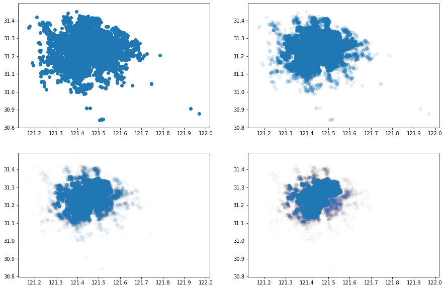

```python
plt.figure(figsize=[15,10])
plt.subplot(2,2,1)
plt.scatter(mobike['start_location_x'],mobike['start_location_y'])
plt.subplot(2,2,2)
plt.scatter(mobike['start_location_x'],mobike['start_location_y'],alpha = 0.1)
plt.subplot(2,2,3)
plt.scatter(mobike['start_location_x'],mobike['start_location_y'],alpha = 0.01)
plt.subplot(2,2,4)
plt.scatter(mobike['start_location_x'],mobike['start_location_y'],alpha = 0.002)
```

### 放大图片以更好地观察

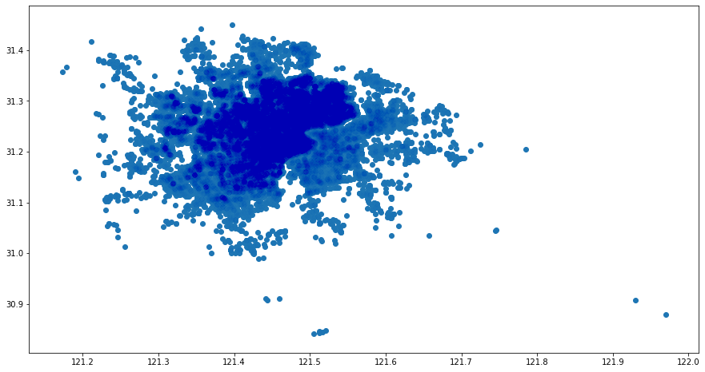

```python
plt.figure(figsize=[15,8])
plt.scatter(mobike['start_location_x'],mobike['start_location_y'])
plt.scatter(mobike['start_location_x'],mobike['start_location_y'],alpha = 0.002,color = 'b')
```

### 进一步放大图片以更好地观察

```
(31.1, 31.35)
```

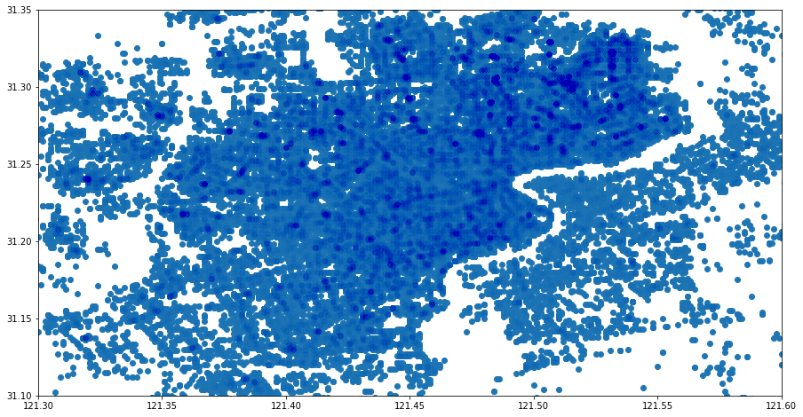

```python
plt.figure(figsize=[15,8])
plt.scatter(mobike['start_location_x'],mobike['start_location_y'])
plt.scatter(mobike['start_location_x'],mobike['start_location_y'],alpha = 0.002,c='b')
plt.xlim(121.3,121.6)
plt.ylim(31.1,31.35)
```

### 去除上图中所有点的叠加图，只保留有透明度的散点图，以更好地观察结果。

```
(31.1, 31.35)
```

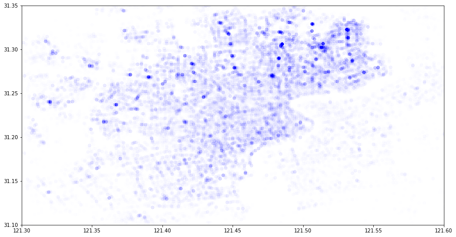

```python
plt.figure(figsize=[15,8])
plt.scatter(mobike['start_location_x'],mobike['start_location_y'],alpha = 0.002,c='b')
plt.xlim(121.3,121.6)
plt.ylim(31.1,31.35)
```

### 上图中，有星星点点的蓝色区域，表示那些区域order订单频率较大

### Talk about some of the relationships you observed in this part of the investigation. How did the feature(s) of interest vary with other features in the dataset?

> 可以观察到某些区域订单数量多

### Did you observe any interesting relationships between the other features (not the main feature(s) of interest)?

> 还没有

## Multivariate Exploration

> Create plots of three or more variables to investigate your data even further. Make sure that your investigations are justified, and follow from your work in the previous sections.

### 把上班下班高峰期7-9点，17-20点的数据提取出来。

#### 早上7:00 - 9：00,17:00 - 20:00（start_time）的数据储存为 df_work, 并分别设置time_category 为 Category类型：

> - 0700组（7：00-7：29），
> - 0730组（7:30 - 7:59）,
> - 0800组（8：00 - 8：29），
> - 0830组（8：30 - 8：59），
> - 1700组（17：00-17：29），
> - 1730组，（17：30-17：59）
> - 1800组，（18：00-18：29）
> - 1830组，（18：30-18：59）
> - 1900组，（19：00-19：29）
> - 1930组。（19：30-19：59）

```python
import time
```

```python
mobike['time_category']=None
```

```python
for i in range(len(mobike)):
    if mobike['start_time'][i].minute <30:
        mobike['time_category'][i] = str(mobike['start_time'][i].hour).rjust(2,'0') + '00'
    else:
        mobike['time_category'][i] = str(mobike['start_time'][i].hour).rjust(2,'0') + '30'
```

```python
mobike['time_category'] = mobike['time_category'].astype('category')
```

```python
temp0700 = mobike[mobike['time_category'] == '0700']
```

```python
times = ['0700','0730','0800','0830','1700','1730','1800','1830','1900','1930']
```

### 分别提取不同时间段的order分布图

> - ### 时间段按每半小时划分，包括7-9am， 17-20pm的10个半小时时间段

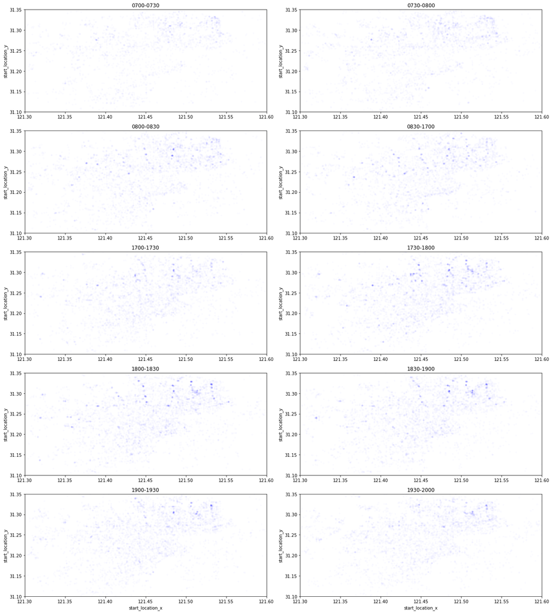

```python
plt.figure(figsize = [18,20])
for i in range(len(times)):
    df_temp = mobike[mobike['time_category']==times[i]]
    plt.subplot(5,2,i+1)
    plt.scatter(df_temp['start_location_x'],df_temp['start_location_y'],alpha = 0.01,c='b',s=10)
    plt.xlim(121.3,121.6)
    plt.ylim(31.1,31.35)
    if i in [8,9]:
        plt.xlabel('start_location_x')
    plt.ylabel('start_location_y')
    if i<9:
        plt.title(times[i]+'-'+times[i+1])
    else:
        plt.title('1930-2000')
plt.tight_layout()
```

### 上图可以看到星星点点的密度较大的位置，但是没有具体数值。

### 下面画二维直方图，以统计高峰时期不同时间段不同位置的具体的order counts

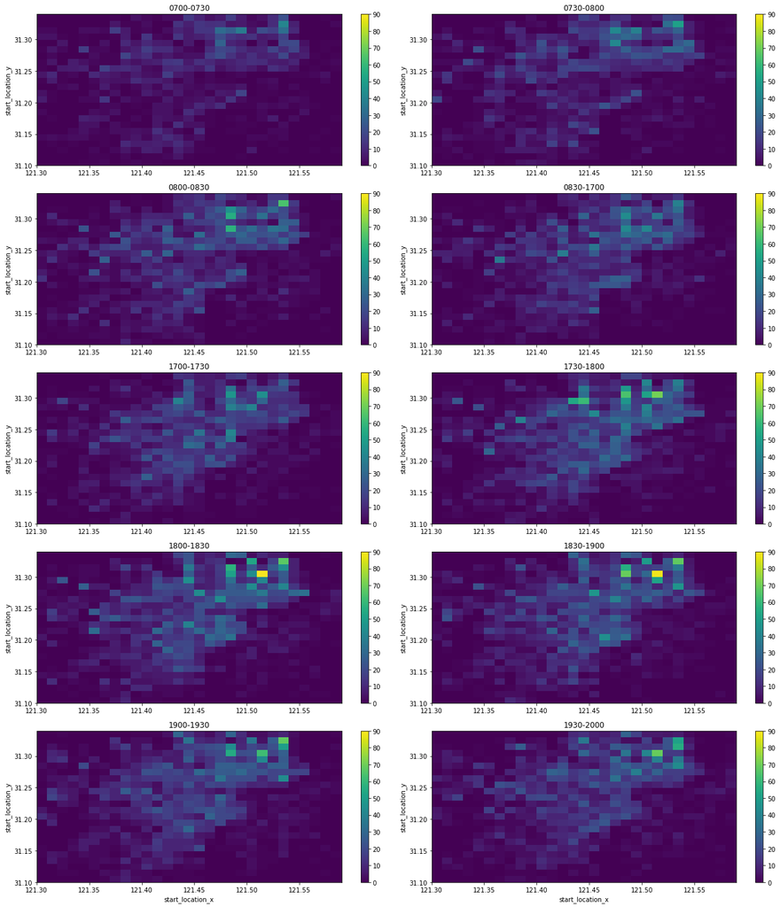

```python
plt.figure(figsize = [18,20])
for i in range(len(times)):
    bins_x = np.arange(121.30, 121.60, 0.01)
    bins_y = np.arange(31.1, 31.35, 0.01)
    plt.subplot(5,2,i+1)
    plt.hist2d(data = mobike[mobike['time_category']==times[i]],x = 'start_location_x', y = 'start_location_y',
               bins = [bins_x,bins_y],vmin=0, vmax=90)
    plt.colorbar()
    if i in [8,9]:
        plt.xlabel('start_location_x')
    plt.ylabel('start_location_y')
    if i<9:
        plt.title(times[i]+'-'+times[i+1])
    else:
        plt.title('1930-2000')
plt.tight_layout()
```

### 可以看出，需求量大的地方大约在：x:121.48-121.55; y:31.25-31.35

### 鉴于有的单车被使用次数很多，用时可能并不长。所以上图并不能完全反映，单车的真正需求。

### - 下一步：把track画出，可以看到真正需求量大的地方。

```python
data = {}
for i in range(len(times)):
    bins_x = np.arange(121.30, 121.60, 0.01)
    bins_y = np.arange(31.1, 31.35, 0.01)
    data[i] = mobike[mobike['time_category']==times[i]]
```

```python
track_x = {}
track_y = {}
for j in range(len(times)):
    df = data[j]
    temp_x = []
    temp_y = []
    for m in range(len(df)):
        temp1 = df['track'][df.index[m]].split('#')
        for i in range(len(temp1)):
            try:
                temp_x.append(float(temp1[i].split(',')[0]))
                temp_y.append(float(temp1[i].split(',')[1]))
            except:
                temp_y.append('31.28')
    track_x[j] = temp_x
    track_y[j] = temp_y
```

```python
count_x = 0
count_y = 0
for i in range(len(times)):
    count_x = count_x +len(track_x[i])
    count_y = count_y +len(track_y[i])
(count_x,count_y)
```

```
(1048877, 1048877)
```

> - 所有track，共有1048877条位置信息。 ##### To do:
> - 1. 把track数据中的位置按照高峰期时间分布画出来。

```python
tracks={}
tracks['track_position_x']=track_x[0]
tracks['track_position_y']=track_y[0]
```

```python
tracks = pd.DataFrame(tracks)
```

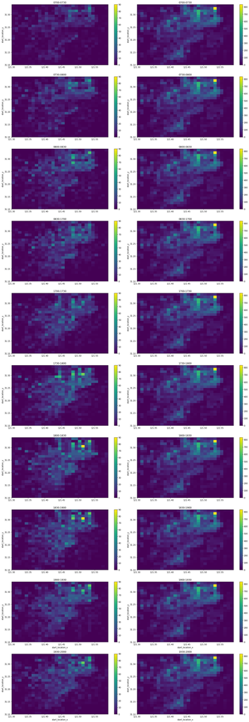

```python
plt.figure(figsize = [18,50])
bins_x = np.arange(121.30, 121.60, 0.01)
bins_y = np.arange(31.1, 31.35, 0.01)
for i in range(len(times)):
    plt.subplot(10,2,2*i+1)
    plt.hist2d(data = mobike[mobike['time_category']==times[i]],x = 'start_location_x', y = 'start_location_y',
               bins = [bins_x,bins_y],vmin=0, vmax=90)
    plt.colorbar()
    if i in [8,9]:
        plt.xlabel('start_location_x')
    plt.ylabel('start_location_y')
    if i<9:
        plt.title(times[i]+'-'+times[i+1])
    else:
        plt.title('1930-2000')

    plt.subplot(10,2,2*i+2)
    plt.hist2d(data = tracks,x = 'track_position_x', y = 'track_position_y',bins = [bins_x,bins_y])
    plt.colorbar()
    if i in [8,9]:
        plt.xlabel('start_location_x')
    plt.ylabel('start_location_y')
    if i<9:
        plt.title(times[i]+'-'+times[i+1])
    else:
        plt.title('1930-2000')

plt.tight_layout()
```

### 在地图中根据经纬度查找黄色位置，得到如下：

[figure not shown]

### Were there any interesting or surprising interactions between features?

> tracks比start_position包含更多信息。

> At the end of your report, make sure that you export the notebook as an html file from the `File > Download as... > HTML` menu. Make sure you keep track of where the exported file goes, so you can put it in the same folder as this notebook for project submission. Also, make sure you remove all of the quote-formatted guide notes like this one before you finish your report!